# Data Visualisation with Ford GoBike System Data

## Investigation Overview

> The overall goal of the presentation is to analyse the dataset Ford GoBike Systema and explore various trends and relationship between the feature variables. At the end of the investigation, we come out with lot of insights about how consumers use the bike sharing services.

## Dataset Overview

> Bay Area Bike Share is a company that provides on-demand bike rentals for customers in San Francisco, Redwood City, Palo Alto, Mountain View, and San Jose. Users can unlock bikes from a variety of stations throughout each city, and return them to any station within the same city.

This data set includes information about individual rides made in a bike-sharing system covering the greater San Francisco Bay area.

Each trip is anonymized and includes:

Trip Duration (seconds), Start Time and Date, End Time and Date, Start Station ID, Start, Station Name, Start Station Latitude, Start Station Longitude, End Station ID, End Station Name, End Station Latitude, End Station Longitude, Bike ID, User Type (Subscriber or Customer – “Subscriber” = Member or “Customer” = Casual), Member Year of Birth, Member Gender

```python
# import all packages and set plots to be embedded inline
import numpy as np
import pandas as pd
import matplotlib.pyplot as plt
import seaborn as sb

%matplotlib inline

# suppress warnings from final output
import warnings
warnings.simplefilter("ignore")
```

```python
# load in the dataset into a pandas dataframe
df=pd.read_csv("/Users/anshulrampal/Downloads/201810-fordgobike-tripdata.csv")
```

```python
df2=df.dropna().reset_index(drop=True)
```

```python
df2.shape
```

```
(191485, 16)
```

## Count of trips by Gender Type

> We can see that male gender type have clearly taken more number of rides in comparison with female and other gender types.

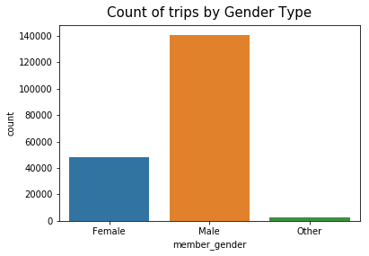

```python
sb.countplot(data=df2,x='member_gender');
plt.title('Count of trips by Gender Type', fontsize=15, y=1.015);
```

## Count of trips by User Type

> Subscribers take more rides than casual riders (customers)

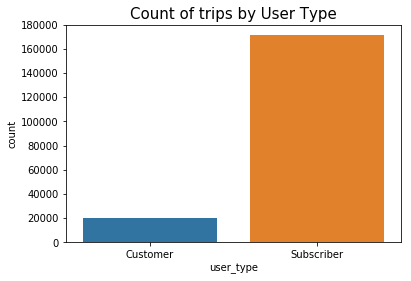

```python
sb.countplot(data=df2,x='user_type');
plt.title('Count of trips by User Type', fontsize=15);
```

```python
df2['member_age'] = 2018-df2['member_birth_year']
df2=df2[df2.member_age<100]
df2.reset_index(drop=True);
```

## Age Distribution of riders

> Clearly as per the distribution, the number of rides taken by people of age groups around 30 are more. Also, elderly people tend to take less number of rides according to the data analysis and visualisation.

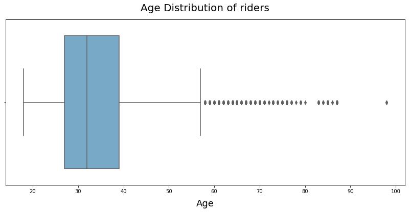

```python
plt.figure(figsize=(14,6))
sb.boxplot(x='member_age', data=df2, palette='Blues', orient='h')
plt.title("Age Distribution of riders", fontsize=20, y=1.03)
plt.xlabel("Age", fontsize=18, labelpad=10);
```

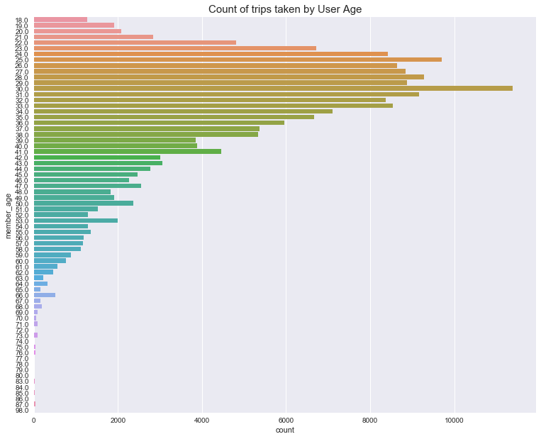

```python
sb.set(rc={'figure.figsize':(12.7,10.27)})
sb.countplot(data=df2,y='member_age');
plt.title('Count of trips taken by User Age', fontsize=15)
plt.savefig('image04.png');
```

```python
df2['start_time'] = pd.to_datetime(df2['start_time'])
df2['start_time_year_month_renamed'] = df2['start_time'].dt.strftime('%y' + '-' + '%m')
df2['datetime'] = pd.to_datetime(df2['start_time'])

x,y=df2.shape
list=[]
for i in range(x):
    list.append(df2['datetime'].iloc[i].strftime('%A'))

df2['weekday']=pd.DataFrame(list, columns=['weekday'])
```

## Count of trips taken by Day of Week

> Maximum number of rides were taken on Wednesday followed by Tuesday. On Saturday and Sunday, less rides were taken. In percentage terms : Most people took ride on Wednesday (19%) followed by Tuesday (18.7%) and Monday(18.1%). Least rides were taken on Sunday(7%).

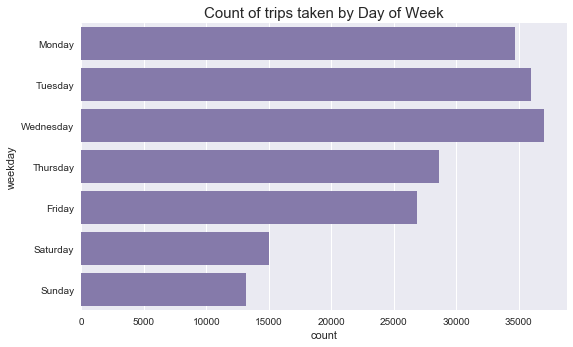

```python
sb.set(rc={'figure.figsize':(8.7,5.27)})
day_order=['Monday','Tuesday','Wednesday','Thursday','Friday','Saturday','Sunday']
base_color=sb.color_palette()[3]
sb.countplot(data=df2,y='weekday',color=base_color,order=day_order);
plt.title('Count of trips taken by Day of Week', fontsize=15);
```

```python
ct_counts=df2.groupby(['member_gender','bike_share_for_all_trip']).size()
ct_counts=ct_counts.reset_index(name='count')
ct_counts=ct_counts.pivot(index='member_gender',columns='bike_share_for_all_trip',values='count')
```

## Bike Share for Trips by Member Gender

> Male took more rides than female. As per the bike share for all trip analysis, the percentage remains the same for both male and female. Male who took sharing rides were 13337 and those of female were 4494.

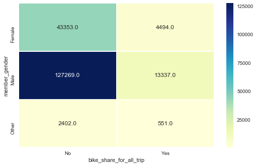

```python
sb.heatmap(ct_counts,annot=True,cmap="YlGnBu",fmt='.1f',linewidths=.5);
```

```python
df2['duration_min'] = df2['duration_sec']/60
```

## Duration of trip by User Age

> Looking at the distribution,we can say that mostly people took rides within 400 minutes of duration and also elderly people took shorter rides less than 80 minute duration or even shorter than that.

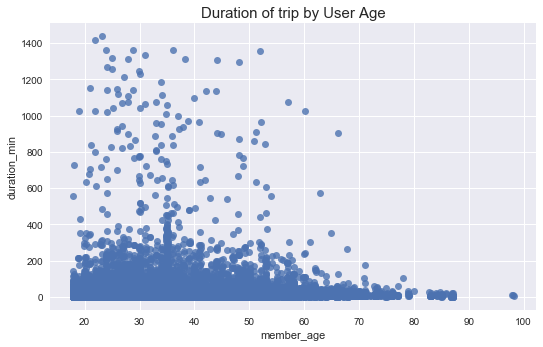

```python
sb.regplot(data=df2,x='member_age',y='duration_min',fit_reg = False,
           x_jitter = 0.2, y_jitter = 0.2);
plt.title('Duration of trip by User Age', fontsize=15);
```

## Average Trip Duration per member gender

> Looking at the distribution,we can say that average trip duration is more for female gender as compared to male and others.

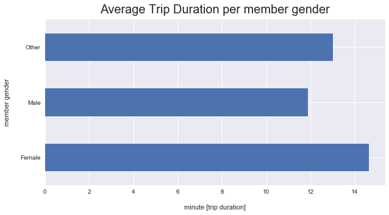

```python
ax = df2.groupby('member_gender')['duration_min'].mean().plot(kind='barh', figsize=(10,5))
ax.set_title('Average Trip Duration per member gender', fontsize=20, y=1.015)
ax.set_ylabel('member gender', labelpad=16)
ax.set_xlabel('minute [trip duration]', labelpad=16);
```

## Average Trip Duration per day of week

> Although most number of rides were taken Wednesday, the longer duration of rides were taken on Sunday and Saturday.

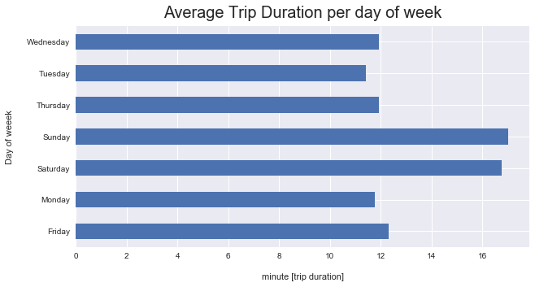

```python
ax = df2.groupby('weekday')['duration_min'].mean().plot(kind='barh', figsize=(10,5))
ax.set_title('Average Trip Duration per day of week', fontsize=20, y=1.015)
ax.set_ylabel('Day of weeek', labelpad=16)
ax.set_xlabel('minute [trip duration]', labelpad=16);
```

## Rider Age, Duration of Trips on Week Days

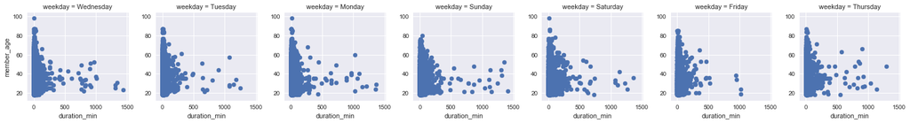

```python
g=sb.FacetGrid(data=df2,col='weekday')
g.map(plt.scatter,'duration_min','member_age');
```